# Self-rated medical-school quality of life in Brazilian medical students

Dataset 7: Resilience, learning environment and quality of life in Brazilian medical students

RSR feasibility analysis

2026-08-03

# Introduction

Tempski and colleagues surveyed a random sample of 1,350 students at 22 Brazilian medical schools in 2011-2012, measuring quality of life (WHOQOL-BREF), the perceived educational environment (DREEM), resilience, depressive symptoms and anxiety in a single cross-sectional questionnaire (Tempski et al., *PLOS ONE* 2015; doi:10.1371/journal.pone.0131535). Alongside the standard instruments, students rated their *medical-school* quality of life on a single 0-10 item. That single item is the outcome a dean can most directly act on, and the DREEM instrument - which breaks the educational environment into five distinct components - is designed precisely to say *which part* of the school experience needs attention.

**Aim.** Among Brazilian medical students, we examined which of the five DREEM domains - perception of learning, perception of teachers, academic self-perception, perception of atmosphere and social self-perception - are independently associated with self-rated medical-school quality of life, adjusting also for sex and stage of the course.

This is a *Purpose 3* analysis: several predictors are of interest and the question is which remain associated with the outcome after mutual adjustment.

# Methods

**Data source.** Multicentre cross-sectional survey of a random sample of 1,350 students drawn from 22 medical schools across Brazil, stratified by stage of the course (basic sciences, clinical sciences, clerkship). All variables used here are complete.

**Variables.** The outcome is `medical_school_qol`, the student’s self-rating of medical-school quality of life on a 0-10 scale (observed range 0 to 10, higher is better). Predictors are sex (reference: female, the larger group), stage of the course (reference: basic sciences, the earliest stage) and the five DREEM subscales, each modelled per one-point increase: perception of learning (0-48), perception of teachers (0-44), academic self-perception (0-32), perception of atmosphere (0-48) and social self-perception (0-28).

The single most important design decision is that `dreem_global` is **excluded**. It is the exact arithmetic sum of the five subscales, so including it alongside them would make the design matrix singular. Using the subscales rather than the global score is the whole point of this analysis - the question is which *component* of the environment carries the association - but it comes at a price: the five subscales correlate with one another at *r* = 0.45 to 0.77, so their variance inflation factors are elevated and are reported and discussed below. No WHOQOL domain, BDI or anxiety scale is used as a predictor: all of them are alternative self-reported wellbeing measures collected on the same form, and adding them would turn the analysis into one questionnaire predicting another.

**Statistical analysis.** Linear regression (`lm()`), justified because the outcome is an ordered 0-10 rating with eleven levels that is conventionally treated as continuous. We fitted a univariable model for each predictor first, then a single multivariable model containing all of them. Predictors were chosen in advance on subject-matter grounds, not by significance. Significance threshold 0.05; estimates are reported with 95% confidence intervals. Assumptions were checked with `performance::check_model()`. Analysis used R version 4.6.0 (2026-04-24) with tidyverse, gtsummary and performance.

**Missing data.** Complete-case analysis: 1350 of 1350 rows were analysed (0 dropped).

# Results

## Sample characteristics

**Table 1. Sample characteristics.**

| **Characteristic** | **N** | **N = 1,350**<sup>1</sup> |
| --- | --- | --- |
| Medical-school quality of life (0-10) | 1,350 | 7.00 (6.00, 8.00) |
| Sex | 1,350 |  |
| Female |  | 714 (53%) |
| Male |  | 636 (47%) |
| Stage of course | 1,350 |  |
| Basic sciences |  | 459 (34%) |
| Clinical sciences |  | 491 (36%) |
| Clerkship |  | 400 (30%) |
| DREEM: perception of learning (0-48) | 1,350 | 28 (23, 33) |
| DREEM: perception of teachers (0-44) | 1,350 | 28 (23, 32) |
| DREEM: academic self-perception (0-32) | 1,350 | 19.0 (16.0, 22.0) |
| DREEM: perception of atmosphere (0-48) | 1,350 | 30 (25, 35) |
| DREEM: social self-perception (0-28) | 1,350 | 16.0 (13.0, 19.0) |

<sup>1</sup> Median (Q1, Q3); n (%)

The median medical-school quality-of-life rating was 7 out of 10, one point below the median overall quality-of-life rating in the same students. Each DREEM subscale sits near the middle of its possible range, with wide spread, and the three stages of the course are represented in similar numbers.

## Exploratory figure

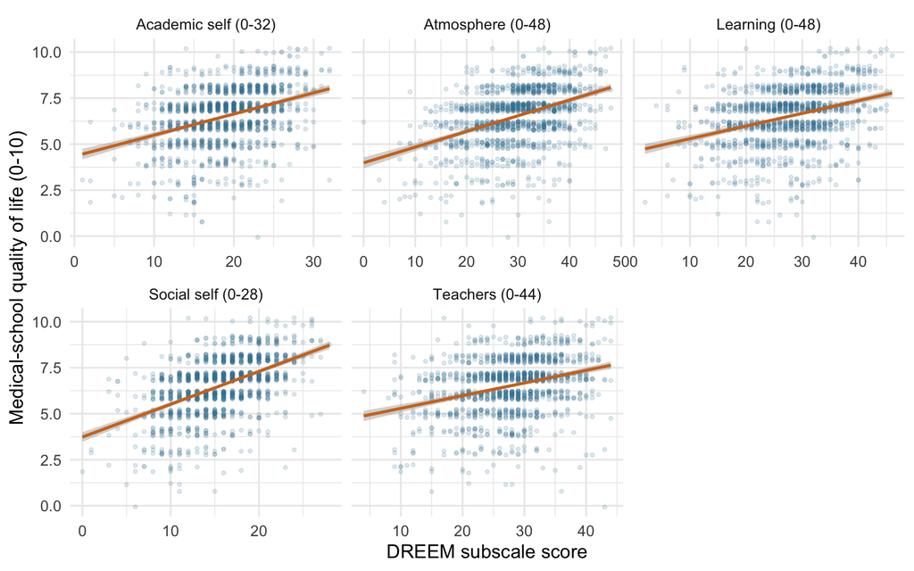

Figure 1. Medical-school quality of life against each DREEM subscale. Points are individual students (jittered vertically); lines are linear smoothers. Note the shared y axis and the differing x ranges.

All five subscales slope upward, and the social self-perception panel is the steepest relative to its narrow 0-28 range - a first hint that how a student feels about their social life at the school, rather than how they rate the teaching, is what tracks their overall verdict on medical school.

## Univariable models

**Univariable linear regression.**

| **Characteristic** | **Beta** | **95% CI** | **p-value** |
| --- | --- | --- | --- |
| Sex |  |  |  |
| Female | — | — |  |
| Male | 0.03 | -0.14, 0.20 | 0.7 |
| Stage of course |  |  |  |
| Basic sciences | — | — |  |
| Clinical sciences | -0.10 | -0.29, 0.10 | 0.3 |
| Clerkship | -0.26 | -0.47, -0.05 | 0.014 |
| DREEM: perception of learning (0-48) | 0.07 | 0.06, 0.08 | <0.001 |
| DREEM: perception of teachers (0-44) | 0.07 | 0.06, 0.08 | <0.001 |
| DREEM: academic self-perception (0-32) | 0.11 | 0.10, 0.13 | <0.001 |
| DREEM: perception of atmosphere (0-48) | 0.09 | 0.08, 0.10 | <0.001 |
| DREEM: social self-perception (0-28) | 0.18 | 0.16, 0.19 | <0.001 |

Abbreviation: CI = Confidence Interval

Every DREEM subscale is strongly associated with medical-school quality of life on its own (all p < 0.001). Social self-perception is the strongest per point: each additional point is associated with a 0.178-point higher rating (95% CI 0.162 to 0.194), so across its full 0-28 range that is about 5.0 points of the 0-10 outcome. Academic self-perception follows (0.115 per point, 95% CI 0.099 to 0.130), then atmosphere (0.085), then learning and teachers (both 0.069 per point). Clerkship students rate their medical-school quality of life -0.26 points lower than basic-sciences students (p = 0.014), and sex shows no crude association (p = 0.72).

## Why adjustment is needed

The crude subscale estimates are almost uninterpretable on their own because the five subscales confound each other. **Perception of atmosphere** is the clearest example: it correlates 0.77 with perception of learning and 0.76 with academic self-perception, and it is also associated with the outcome, so the crude learning coefficient is substantially a measure of atmosphere and vice versa. A student who is generally positive about their school marks every DREEM item higher, which is exactly the structure that produces five separately significant crude coefficients when only one or two components matter. **Social self-perception** confounds the other four in the same way: it correlates 0.45 to 0.63 with them and it is by far the strongest crude predictor, so a large share of the crude learning, teachers, academic-self and atmosphere associations is really social self-perception. Beyond the DREEM subscales, **stage of the course** is a genuine confounder in the ordinary sense: clerkship students rate both the educational environment and their medical-school quality of life lower than basic-sciences students, so it is associated with predictor and outcome alike and must be held fixed. Fitting all seven predictors together answers the question the crude models cannot: which *component* of the environment carries the association once general positivity is accounted for.

## Multivariable model

**Multivariable linear regression.**

| **Characteristic** | **Beta** | **95% CI** | **p-value** |
| --- | --- | --- | --- |
| Sex |  |  |  |
| Female | — | — |  |
| Male | -0.12 | -0.26, 0.02 | 0.10 |
| Stage of course |  |  |  |
| Basic sciences | — | — |  |
| Clinical sciences | 0.03 | -0.14, 0.20 | 0.8 |
| Clerkship | -0.05 | -0.24, 0.13 | 0.6 |
| DREEM: perception of learning (0-48) | 0.00 | -0.02, 0.02 | >0.9 |
| DREEM: perception of teachers (0-44) | 0.00 | -0.02, 0.01 | 0.7 |
| DREEM: academic self-perception (0-32) | 0.01 | -0.01, 0.04 | 0.3 |
| DREEM: perception of atmosphere (0-48) | 0.03 | 0.01, 0.05 | <0.001 |
| DREEM: social self-perception (0-28) | 0.14 | 0.12, 0.16 | <0.001 |

Abbreviation: CI = Confidence Interval

**Model fit**

| Statistic | Value |
| --- | --- |
| R-squared | 0.276 |
| Adjusted R-squared | 0.271 |
| Residual SE | 1.33 |
| n | 1350 |
| Model df | 8 |

The model explains 27.6% of the variance in self-rated medical-school quality of life (adjusted R-squared 0.271). Only two of the seven predictors survive mutual adjustment. **Social self-perception** dominates: each additional point is associated with 0.140 (95% CI 0.119 to 0.161) points of medical-school quality of life holding the other four DREEM domains, sex and stage fixed - about 3.9 points of the 0-10 outcome across the full subscale range. **Perception of atmosphere** retains a smaller independent association (0.031 (95% CI 0.013 to 0.050) per point). Perception of learning (-0.001 (95% CI -0.018 to 0.016)), perception of teachers (-0.004 (95% CI -0.020 to 0.013)) and academic self-perception (0.013 (95% CI -0.011 to 0.038)) all have confidence intervals spanning zero, and the first two have point estimates on the wrong side of it. Sex (-0.12 (95% CI -0.26 to 0.02)) and stage of the course (clerkship -0.05 (95% CI -0.24 to 0.13), clinical sciences 0.03 (95% CI -0.14 to 0.20)) show no independent association. These are conditional associations from a cross-sectional survey and describe covariation, not the effect of changing any DREEM domain.

## Unadjusted versus adjusted

**Table 2. Unadjusted and adjusted estimates.**

| **Characteristic** | **Unadjusted** **Beta** | **Unadjusted** **95% CI** | **Unadjusted** **p-value** | **Adjusted** **Beta** | **Adjusted** **95% CI** | **Adjusted** **p-value** |
| --- | --- | --- | --- | --- | --- | --- |
| Sex |  |  |  |  |  |  |
| Female | — | — |  | — | — |  |
| Male | 0.03 | -0.14, 0.20 | 0.7 | -0.12 | -0.26, 0.02 | 0.10 |
| Stage of course |  |  |  |  |  |  |
| Basic sciences | — | — |  | — | — |  |
| Clinical sciences | -0.10 | -0.29, 0.10 | 0.3 | 0.03 | -0.14, 0.20 | 0.8 |
| Clerkship | -0.26 | -0.47, -0.05 | 0.014 | -0.05 | -0.24, 0.13 | 0.6 |
| DREEM: perception of learning (0-48) | 0.07 | 0.06, 0.08 | <0.001 | 0.00 | -0.02, 0.02 | >0.9 |
| DREEM: perception of teachers (0-44) | 0.07 | 0.06, 0.08 | <0.001 | 0.00 | -0.02, 0.01 | 0.7 |
| DREEM: academic self-perception (0-32) | 0.11 | 0.10, 0.13 | <0.001 | 0.01 | -0.01, 0.04 | 0.3 |
| DREEM: perception of atmosphere (0-48) | 0.09 | 0.08, 0.10 | <0.001 | 0.03 | 0.01, 0.05 | <0.001 |
| DREEM: social self-perception (0-28) | 0.18 | 0.16, 0.19 | <0.001 | 0.14 | 0.12, 0.16 | <0.001 |

Abbreviation: CI = Confidence Interval

This is the most dramatic unadjusted-versus-adjusted table in the dataset, and almost all of the movement is collinearity rather than confounding in the usual sense. **Perception of learning** and **perception of teachers** each go from a highly significant 0.069 and 0.069 (both p < 0.001) to -0.001 and -0.004 - both cross zero and become non-significant (p = 0.91 and 0.66). Their entire crude association was shared with the other three subscales. **Academic self-perception** loses almost as much, from 0.115 to 0.013 (12% retained) and also becomes non-significant. **Perception of atmosphere** keeps 37% (0.085 to 0.031) and stays significant.

By contrast **social self-perception** barely moves, from 0.178 to 0.140 - 78% retained - and is the only predictor whose crude story survives intact. Among the non-DREEM terms, **clerkship** loses its significance (-0.26, p = 0.014, to -0.05, p = 0.59): clerkship students’ lower ratings of medical school are explained by their lower DREEM scores. **Sex** moves slightly away from the null in the negative direction (0.03 to -0.12) but remains non-significant in both models. The right reading of this table is not that teaching and learning do not matter, but that these five subscales are too correlated for the model to apportion credit among them; only the two most distinctive - social self-perception and atmosphere - emerge with separable signal.

## Diagnostics

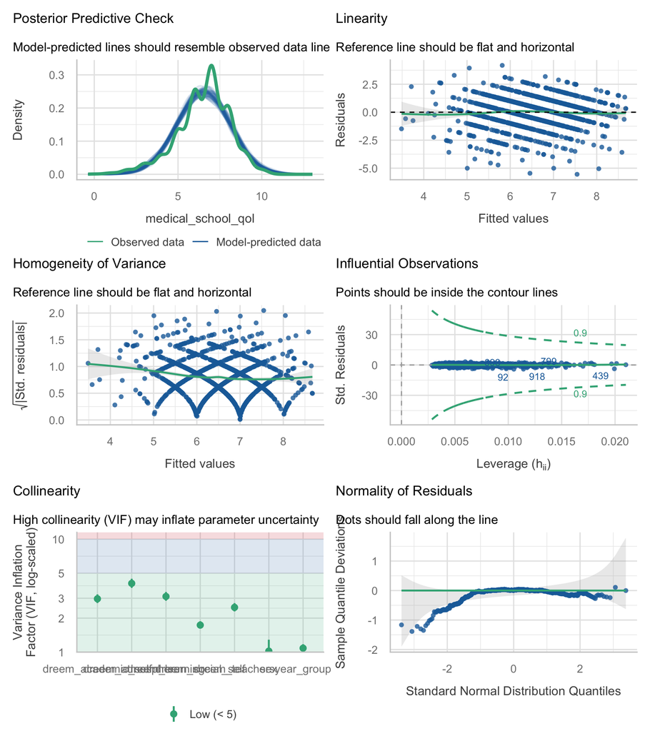

**Variance inflation factors**

| Term | VIF | Tolerance |
| --- | --- | --- |
| dreem_atmosphere | 4.06 | 0.246 |
| dreem_learning | 3.11 | 0.321 |
| dreem_academic_self | 2.97 | 0.337 |
| dreem_teachers | 2.49 | 0.402 |
| dreem_social_self | 1.74 | 0.576 |
| year_group | 1.08 | 0.922 |
| sex | 1.02 | 0.979 |

**Collinearity - the main diagnostic finding here.** The five DREEM subscales have VIFs of 4.06, 3.11, 2.97, 2.49, 1.74, the largest being perception of atmosphere at 4.06. All are below the conventional cut-off of 5, so the model is estimable and the coefficients are not numerically unstable - but a VIF of 4.1 means the standard error for atmosphere is 2.0 times what it would be if the subscales were uncorrelated. That inflation is the direct cause of the three non-significant subscale coefficients above, and it should be reported alongside them rather than left to the reader to infer.

**Linearity.** The fitted-versus-residual reference line is close to flat with a mild downward drift at the top of the fitted range, where the 0-10 rating hits its ceiling.

**HC3 robust standard errors (sensitivity check)**

| term | estimate | robust SE | statistic | p.value |
| --- | --- | --- | --- | --- |
| (Intercept) | 3.344 | 0.209 | 15.99 | < 0.001 |
| sexMale | -0.121 | 0.074 | -1.63 | 0.10347 |
| year_groupClinical sciences | 0.027 | 0.085 | 0.32 | 0.75196 |
| year_groupClerkship | -0.051 | 0.100 | -0.51 | 0.60942 |
| dreem_learning | -0.001 | 0.009 | -0.10 | 0.91691 |
| dreem_teachers | -0.004 | 0.010 | -0.38 | 0.70377 |
| dreem_academic_self | 0.013 | 0.013 | 1.03 | 0.30346 |
| dreem_atmosphere | 0.031 | 0.010 | 3.06 | 0.00229 |
| dreem_social_self | 0.140 | 0.012 | 11.82 | < 0.001 |

No coefficient changes its significance status under HC3, so the conclusions do not depend on the constant-variance assumption.

**Influential points.** No observation exceeds the Cook’s distance threshold; the largest is 0.033.

# Discussion

How Brazilian medical students rate their medical-school quality of life is tracked overwhelmingly by one component of the educational environment: their social self-perception - whether they have good friends at the school, whether they are lonely, whether they are too tired to enjoy the course. Once that is held fixed, perception of the teachers and perception of the learning have no detectable independent association at all, and perception of the atmosphere retains only a small one. Practically, this points a dean towards the social fabric of the school - peer support, timetabling that leaves room for a life, accommodation, cohort size - rather than towards teaching quality, which dominates most quality-improvement conversations. The caveat is large, however: the five DREEM subscales are so intercorrelated that “teaching does not matter” is not a safe conclusion, only “teaching adds nothing once social experience is known”.

**Limitations.** *Collinearity among the exposures.* With subscale VIFs up to 4.1 the model cannot cleanly separate the five DREEM components, and the three null coefficients reflect shared variance as much as absent association. A model using `dreem_global` alone would be cleaner but could not answer the question posed. *Single-item outcome.* Medical-school quality of life is one 0-10 question with no reliability estimate; measurement error in it biases every coefficient toward the null and puts a ceiling on R-squared. *Clustering is not modelled.* Students came from 22 medical schools, but the released file carries no school identifier - only `school_legal_status` and `school_location` - and DREEM scores are substantially a property of the school rather than the student. The effective sample size for anything school-level is therefore far below 1350, standard errors are too narrow, and no random intercept can be fitted. *Cross-sectional design and common-method bias.* DREEM and the outcome were answered on the same form minutes apart; a student in a bad mood marks both down, which inflates every association reported here. *Reverse direction.* A student who is unhappy at medical school will describe their social self-perception more negatively, so the arrow may point from the outcome to the predictor.

**Future work.** Measure DREEM at the start of the year and the quality-of-life rating at the end, retain the school identifier, and fit a mixed model so that school-level environment can be separated from individual perception of it.

# Feasibility notes

*Not part of a student report.*